# NewerHoods

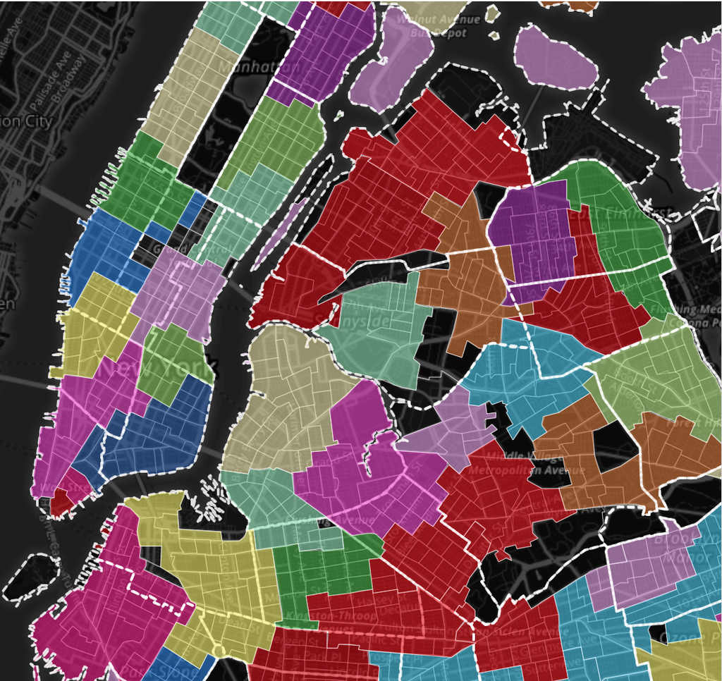

NewerHoods

New York City is the City of Neighborhoods. These neighborhoods have gone through a lot of changes over the last decade, but our definitions of neighborhoods remain the same. NewerHoods is a tool that allows you to reimagine New York City neighborhoods using Open Data and Machine Learning. NewerHoods lets you select specific characteristics to visualize the clusters on a map of New York City, find similar neighborhoods and compare against existing geographic divisions.

We use multiple open datasets to generate characteristics related to housing, crime and noise levels. These characteristics/features are evaluated at the census tract level which are then clustered to find pockets of tracts homogenous in terms of the characteristics. These are what we call NewerHoods.

### Directory Structure

`/data` contains just the cleaned/transformed data sets used directly by the Shiny App.

`/src` contains all the code to merge and clean the data sets, extract features from it, and cluster the features.

### Running the App locally

```r
Sys.setenv('MAPBOX_ACCESS_TOKEN'="YOUR TOKEN HERE")
```

Run the App

```r
library(shiny)
runApp("newerhoods")
```

### Data Sources

1. [NYC Annualized Property Sales Data (2012-2017)](https://www1.nyc.gov/site/finance/taxes/property-annualized-sales-update.page)
2. [MapPLUTO (18v1)](https://www1.nyc.gov/site/planning/data-maps/open-data/dwn-pluto-mappluto.page)
3. [Geoclient API v1.1](https://developer.cityofnewyork.us/api/geoclient-api)
4. [Property Assessment Roll Archives](https://www1.nyc.gov/site/finance/taxes/property-assessment-roll-archives.page)
5. [NYPD Complaint Data Historic](https://data.cityofnewyork.us/Public-Safety/NYPD-Complaint-Data-Historic/qgea-i56i)
6. [311 Service Requests from 2010 to Present](https://data.cityofnewyork.us/Social-Services/311-Service-Requests-from-2010-to-Present/erm2-nwe9)

### References

1. [ClustGeo: an R package for hierarchical clustering with spatial constraints](https://arxiv.org/abs/1707.03897)
2. [Making Neighborhoods - Understanding New York City Transitions 2000-2010](http://chpcny.org/assets/MakingNeighborhoodsPaper.pdf)